# Project 2, Part 2\n

### Saiida Webb, @03080915

```python
import pandas as pd
import numpy as np
import seaborn as sns
import matplotlib.pyplot as plt
```

#### This is a mandatory first step when working with datasets and especially with visualizations. It is important to upload libraries so that we can access built-in functions.

```python
df = pd.read_csv("clean_crime_data.csv")
df
```

|  | DR_NO | Date Rptd | DATE OCC | TIME OCC | AREA | AREA NAME | Rpt Dist No | Part 1-2 | Crm Cd Desc | Vict Age | Vict Sex | Vict Descent | Status | Status Desc | LOCATION | Sex_numeric |
| --- | --- | --- | --- | --- | --- | --- | --- | --- | --- | --- | --- | --- | --- | --- | --- | --- |
| 0 | 190326475 | 03/01/2020 12:00:00 AM | 03/01/2020 12:00:00 AM | 2130 | 7 | Wilshire | 784 | 1 | VEHICLE - STOLEN | 37.0 | M | O | AA | Adult Arrest | 1900 S LONGWOOD AV | 1.0 |
| 1 | 200106753 | 02/09/2020 12:00:00 AM | 02/08/2020 12:00:00 AM | 1800 | 1 | Central | 182 | 1 | BURGLARY FROM VEHICLE | 47.0 | M | O | IC | Invest Cont | 1000 S FLOWER ST | 1.0 |
| 2 | 200320258 | 11/11/2020 12:00:00 AM | 11/04/2020 12:00:00 AM | 1700 | 3 | Southwest | 356 | 1 | BIKE - STOLEN | 19.0 | Unknown | X | IC | Invest Cont | 1400 W 37TH ST | 2.0 |
| 3 | 200907217 | 05/10/2023 12:00:00 AM | 03/10/2020 12:00:00 AM | 2037 | 9 | Van Nuys | 964 | 1 | SHOPLIFTING-GRAND THEFT ($950.01 & OVER) | 19.0 | M | O | IC | Invest Cont | 14000 RIVERSIDE DR | 1.0 |
| 4 | 200412582 | 09/09/2020 12:00:00 AM | 09/09/2020 12:00:00 AM | 630 | 4 | Hollenbeck | 413 | 1 | VEHICLE - STOLEN | 37.0 | Unknown | H | IC | Invest Cont | 200 E AVENUE 28 | 2.0 |
| ... | ... | ... | ... | ... | ... | ... | ... | ... | ... | ... | ... | ... | ... | ... | ... | ... |
| 1005028 | 252104053 | 01/19/2025 12:00:00 AM | 01/17/2025 12:00:00 AM | 1530 | 21 | Topanga | 2114 | 1 | THEFT-GRAND ($950.01 & OVER)EXCPT,GUNS,FOWL,LI... | 37.0 | M | W | IC | Invest Cont | 22200 ELKWOOD ST | 1.0 |
| 1005029 | 250304214 | 02/23/2025 12:00:00 AM | 02/21/2025 12:00:00 AM | 1530 | 3 | Southwest | 358 | 1 | VEHICLE - STOLEN | 37.0 | Unknown | H | IC | Invest Cont | 3600 MCCLINTOCK AV | 2.0 |
| 1005030 | 250304203 | 02/20/2025 12:00:00 AM | 02/13/2025 12:00:00 AM | 2100 | 3 | Southwest | 325 | 1 | VEHICLE, STOLEN - OTHER (MOTORIZED SCOOTERS, B... | 37.0 | Unknown | H | IC | Invest Cont | 2600 ELLENDALE PL | 2.0 |
| 1005031 | 250504051 | 01/14/2025 12:00:00 AM | 01/14/2025 12:00:00 AM | 1250 | 5 | Harbor | 509 | 1 | ROBBERY | 15.0 | F | H | IC | Invest Cont | 24300 WESTERN AV | 0.0 |
| 1005032 | 251604136 | 02/27/2025 12:00:00 AM | 02/27/2025 12:00:00 AM | 1550 | 16 | Foothill | 1664 | 1 | VEHICLE - STOLEN | 37.0 | Unknown | H | AA | Adult Arrest | 11900 SHELDON ST | 2.0 |

1005033 rows × 16 columns

#### This allows us to upload to CSV into the file. This is the cleaned version of the original dataset.

### SECTION I: INDIVIDUAL, COMPARATIVE AND GROUPED VISUALIZATIONS

1. Create at least two of the following:
- A histogram or boxplot for a numerical column (e.g., income, score, age, etc.).
- A bar chart for a categorical column (e.g., region, department, gender, etc.).
- A count plot showing frequency distribution of a key variable.

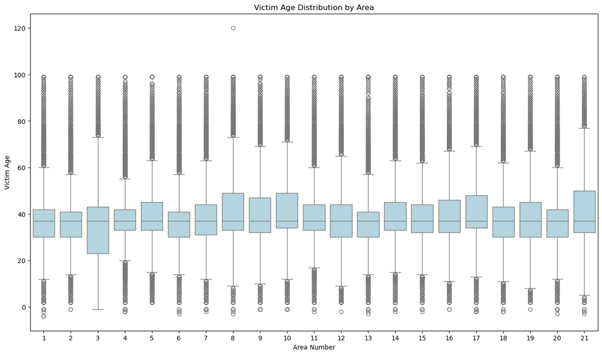

```python
plt.figure(figsize=(16, 9))
sns.boxplot(data=df, x='AREA', y='Vict Age', color='lightblue')
plt.title("Victim Age Distribution by Area")
plt.xlabel("Area Number")
plt.ylabel("Victim Age")
plt.show()
```

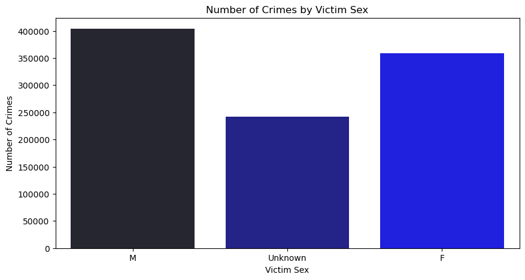

```python
plt.figure(figsize=(10, 5))
sns.countplot(data=df, x='Vict Sex', color="blue", hue='Vict Sex')
plt.title("Number of Crimes by Victim Sex")
plt.xlabel("Victim Sex")
plt.ylabel("Number of Crimes")
plt.show()
```

#### What does this visualization reveal about the distribution or spread of values?

#### For the countplot reflecting data from Victim Sex and number of crimes committed, I analyzed the amount of amount of victims of crimes by gender. This visualization shows that males were more often victims of crimes when compared to females and non-gendered individuals. Non-gendered individuals having the lowest recorded victimizations does not mean that non-binary individuals are less likely to become victims, but it more likely reflects that more often than not, the sexes of victims of crimes are identified in the report.

2. Use .groupby() and visualization to compare across categories:\n
- A bar plot or line plot comparing average or total values across categories.

```python
df_rand_150= df.sample(150)
df_rand_150
```

|  | DR_NO | Date Rptd | DATE OCC | TIME OCC | AREA | AREA NAME | Rpt Dist No | Part 1-2 | Crm Cd Desc | Vict Age | Vict Sex | Vict Descent | Status | Status Desc | LOCATION | Sex_numeric |
| --- | --- | --- | --- | --- | --- | --- | --- | --- | --- | --- | --- | --- | --- | --- | --- | --- |
| 430616 | 221822793 | 12/28/2022 12:00:00 AM | 12/27/2022 12:00:00 AM | 1930 | 18 | Southeast | 1806 | 1 | VEHICLE - STOLEN | 37.0 | Unknown | H | IC | Invest Cont | 91ST | 2.0 |
| 83340 | 200410013 | 06/20/2020 12:00:00 AM | 06/09/2020 12:00:00 AM | 800 | 4 | Hollenbeck | 448 | 2 | BUNCO, GRAND THEFT | 33.0 | F | H | IC | Invest Cont | 2500 ALCAZAR ST | 0.0 |
| 872857 | 231209289 | 03/30/2023 12:00:00 AM | 03/30/2023 12:00:00 AM | 1455 | 12 | 77th Street | 1203 | 1 | ASSAULT WITH DEADLY WEAPON, AGGRAVATED ASSAULT | 31.0 | M | H | AA | Adult Arrest | 4400 S WESTERN AV | 1.0 |
| 240028 | 210905023 | 01/28/2021 12:00:00 AM | 01/28/2021 12:00:00 AM | 1000 | 9 | Van Nuys | 969 | 1 | ROBBERY | 48.0 | M | H | AA | Adult Arrest | 12900 MAGNOLIA BL | 1.0 |
| 52537 | 200305079 | 01/19/2020 12:00:00 AM | 01/19/2020 12:00:00 AM | 1920 | 3 | Southwest | 319 | 1 | ASSAULT WITH DEADLY WEAPON, AGGRAVATED ASSAULT | 33.0 | M | H | AA | Adult Arrest | 1900 ESTRELLA AV | 1.0 |
| ... | ... | ... | ... | ... | ... | ... | ... | ... | ... | ... | ... | ... | ... | ... | ... | ... |
| 408947 | 210811765 | 07/14/2021 12:00:00 AM | 06/28/2021 12:00:00 AM | 1200 | 8 | West LA | 893 | 2 | THEFT OF IDENTITY | 57.0 | F | W | IC | Invest Cont | 11200 EXPOSITION BL | 0.0 |
| 636843 | 220119535 | 08/31/2022 12:00:00 AM | 08/31/2022 12:00:00 AM | 2210 | 1 | Central | 139 | 1 | BURGLARY FROM VEHICLE | 27.0 | M | A | IC | Invest Cont | 700 TRACTION AV | 1.0 |
| 683941 | 231106221 | 02/28/2023 12:00:00 AM | 02/26/2023 12:00:00 AM | 1120 | 11 | Northeast | 1109 | 2 | VIOLATION OF RESTRAINING ORDER | 32.0 | F | W | AO | Adult Other | 1700 COLORADO BL | 0.0 |
| 641169 | 220114232 | 06/12/2022 12:00:00 AM | 06/05/2022 12:00:00 AM | 2230 | 1 | Central | 176 | 1 | BURGLARY FROM VEHICLE | 40.0 | M | W | IC | Invest Cont | 8TH ST | 1.0 |
| 177258 | 201905445 | 02/02/2020 12:00:00 AM | 02/02/2020 12:00:00 AM | 930 | 19 | Mission | 1984 | 1 | BURGLARY FROM VEHICLE | 32.0 | F | H | IC | Invest Cont | 8800 WILLIS AV | 0.0 |

150 rows × 16 columns

#### Because there is so much data in the original dataset, I chose a random sample of 150 to represent the data and correlated values. This makes the visualization easier to interpret because less values reflects simplicity and cleanliness in the plot, especially when considering the amount of diferent crime descriptions.

[figure not shown]

```python
top_crimes = df_rand_150['Crm Cd Desc'].value_counts().head(20).index

df_top_crimes = df_rand_150[df_rand_150['Crm Cd Desc'].isin(top_crimes)]

plt.figure(figsize=(14, 8))
sns.countplot(data=df_top_crimes, x='Vict Sex', hue='Crm Cd Desc', palette='Set2')
plt.title("Crime Type Distribution by Victim Sex (Top 5 Crimes)")
plt.xlabel("Victim Sex")
plt.ylabel("Number of Crimes")
plt.legend(title="Crime Description", bbox_to_anchor=(1.05, 1),loc='upper left')
plt.show()
```

#### Explain: What patterns or differences do you observe among the groups?

#### Note that I only used the top 20 different types of crime committeed with the function "value_count().head(20)." I did this because if I used all of the different crime descriptions in the visualization, it would have been less clear and made it more difficult to interpret the meanings and distinctions of the colors (crime descriptions) in relationship to the sex of the victim. This count plot shows that stolen cars were the most recurring crimes committed agaisnt people with unidentifiable genders. This makes sense because stolen vehicles can and often are reported to third parties or digitally. Females were most often victimized by identity theft. Males were most often victimized by assault with a deadly weapon/aggravated assault. Across the bord, embezzlement was a relativley rare crime committeed against all sexes.

### SECTION II: RELATIONSHIP VISUALIZATIONS (10 POINTS)

#### Use visualizations that reveal relationships between two numerical or mixed variables:

- A scatter plot.
- A heatmap of correlations.

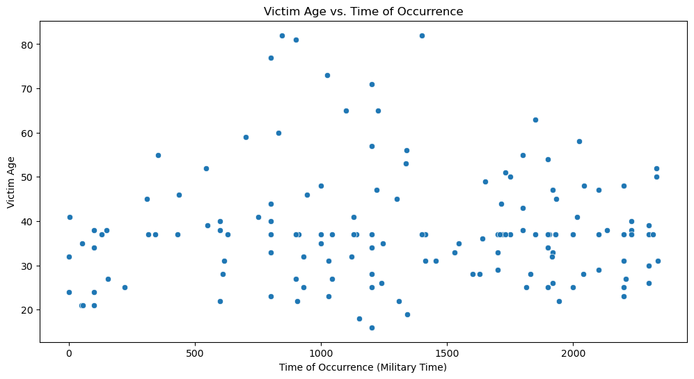

```python
plt.figure(figsize=(12, 6))
sns.scatterplot(data=df_rand_150, x='TIME OCC', y='Vict Age')
plt.title("Victim Age vs. Time of Occurrence")
plt.xlabel("Time of Occurrence (Military Time)")
plt.ylabel("Victim Age")
plt.show()
```

#### The x-axis uses data time from the TIME OCC column which reflects military time. This means that midnight is shown as 0 and 11:00 PM is shown as 2300. This puts the range of the full day from 0 to 2300, as opposed to 12:00 AM to 11:59 PM. The scatter plot shows the relationship between Victim Age and time of occurrance. More simplified, it shows what age groups were more often victimized at different times of the day. While there appears to be a relativley weak correlation between age and time of crime occurrance, the outliers show trends. Older people over the age of 50 are more likely to be victimized between the range of the early morning and afternoon (7:00 AM to 3:00 PM). Young people under forty were generally vicitmized at similar rates throughout the day. There is a slightly higher concentration of crimes occurring later on in the day. The data appears in general chunks, with clusters appearing shortly after midnight, aorund midday, and towards the end of the night.

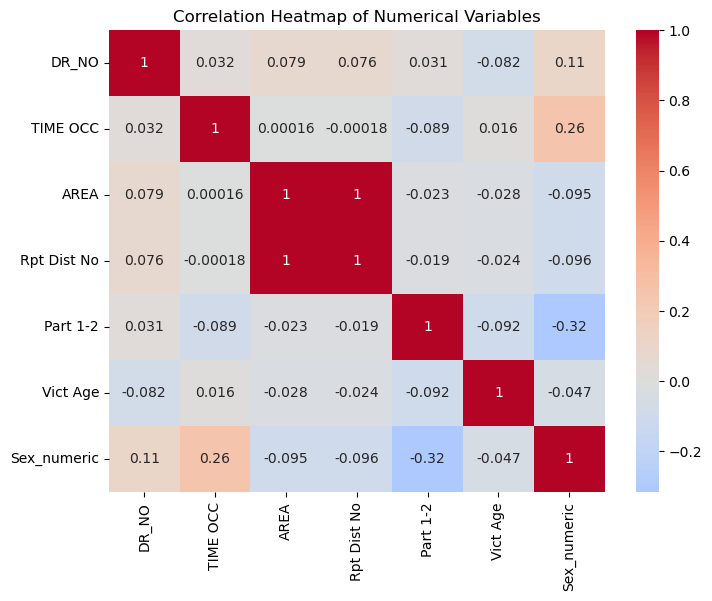

```python
plt.figure(figsize=(8, 6))
sns.heatmap(df_rand_150.corr(numeric_only=True), annot=True, cmap='coolwarm', center=0)
plt.title("Correlation Heatmap of Numerical Variables")
plt.show()
```